# Etude des liens de correlation entre des indicateur de pression plans d’eau et l’indicateur de qualité des eaux IPR (Indice Poisson Rivière)

Josselin BARRY

2024-07-25

## Chargement des packages et des données

```
## udunits database from C:/Users/josselin.barry/AppData/Local/R/win-library/4.2/units/share/udunits/udunits2.xml
```

[output not shown]

On cherche ici à tester des liens de corrélation entre des indicateurs « plans d’eau » calculés à l’échelle des bassins versants des stations IPR et les notes IPR sur ces stations. Notre choix a aussi retenu des métriques IPR permettant de cibler certains des impacts des plans d’eau.

Le principe est de modéliser la note IPR en fonction des différentes variables (a priori de pression car l’IPR est réputé insensible aux variables environnementales « naturelles ») et de voir lesquelles contribuent significativement à expliquer la variabilité des notes IPR.

Dans une telle démarche il n’est pas possible de mettre « en vrac » une multitude de variables explicatives. Celles-ci doivent être sélectionnées pour leur pertinence et ne doivent pas être exagérément corrélées entre elles. En modèle linéaire, chacune des variables doit être à peu près distribuée normalement (histogramme en cloche).

L’examen des sorties des modèles conduit à itérer pour les améliorer, en particulier en écartant des cas (des stations IPR) trop atypiques ou en simplifiant les modèles en excluant les variables explicatives non strictement nécessaires.

## Regroupement des variables par variables de synthèse ou ACP

Une des méthodes pour éviter un trop grand nombre de variables explicative trop corrélées entre elles est de les soumettre à une Analyse en Composantes Principales (ACP). Les composantes principales (=les axes) peuvent être utilisées comme variables de synthèse.

Les variables sont loguées pour que leurs distributions se rapprochent de la normalité, puis on étudie la possibilité de regrouper certaines variables fortement corrélées entres elles, par une variable de synthèse (ACP). On représente donc la matrice de corrélation entre les variables pour dégager des groupes de variables qui seront ensuite soumis à ces ACP séparées.

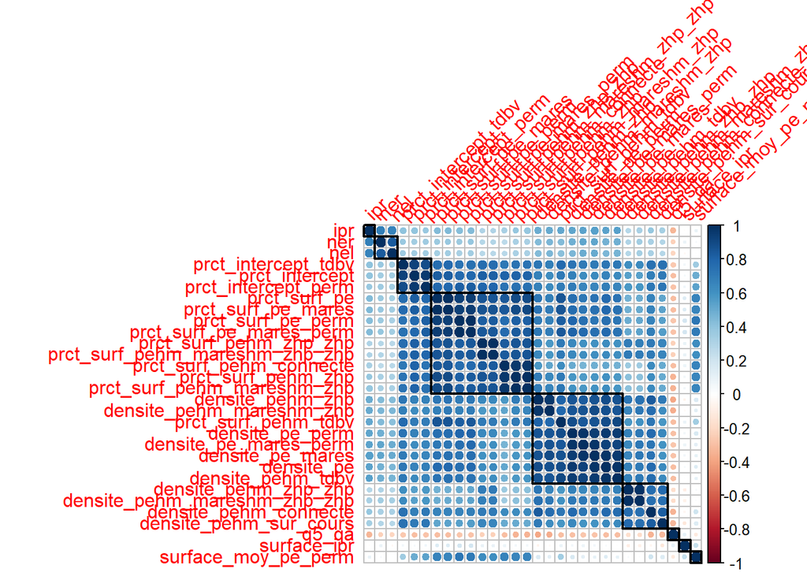

**Plusieurs variables de synthèse (ACP) se dessinent :**

- **Les indicateurs de taux de linéaire intercepté**

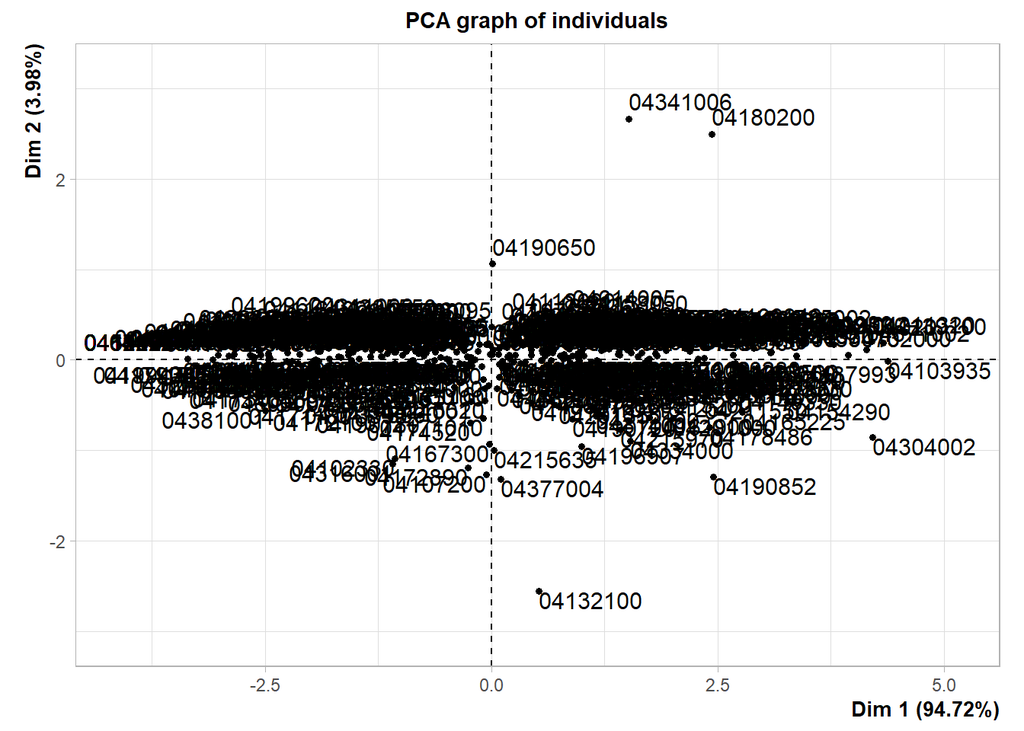

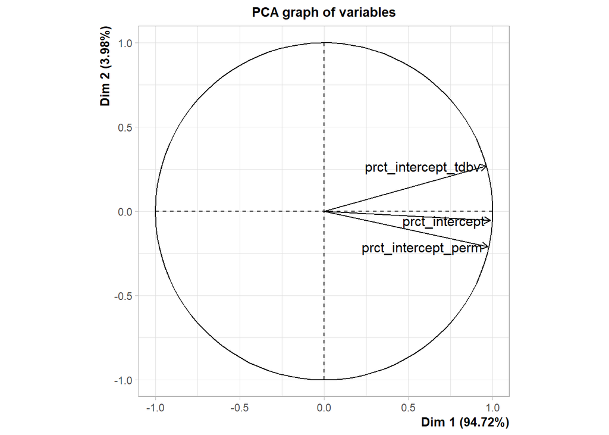

- **Les indicateurs de densité surfacique**

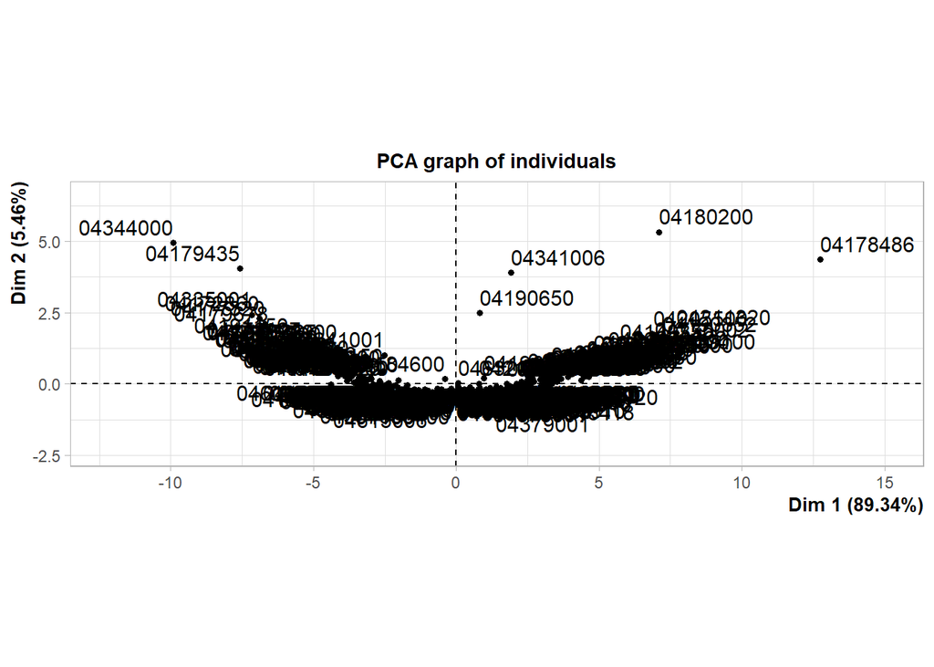

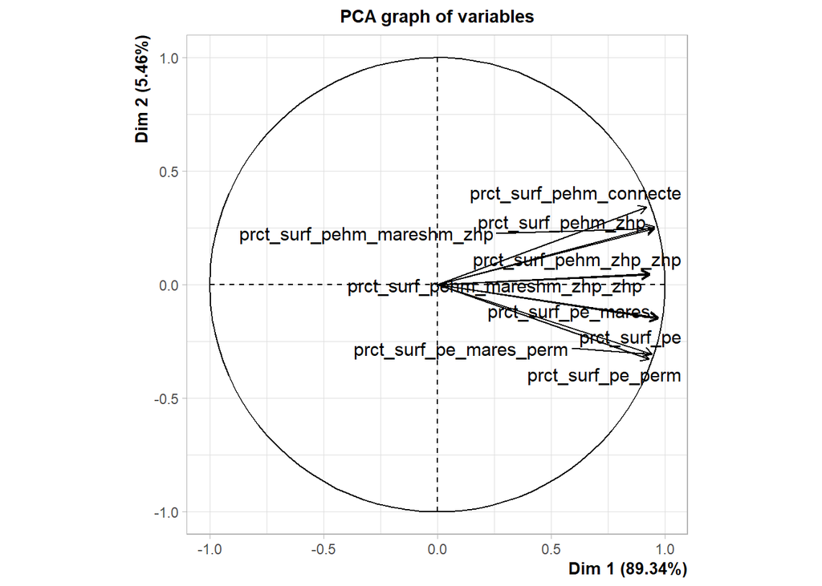

- **Les indicateurs de densité numérique**

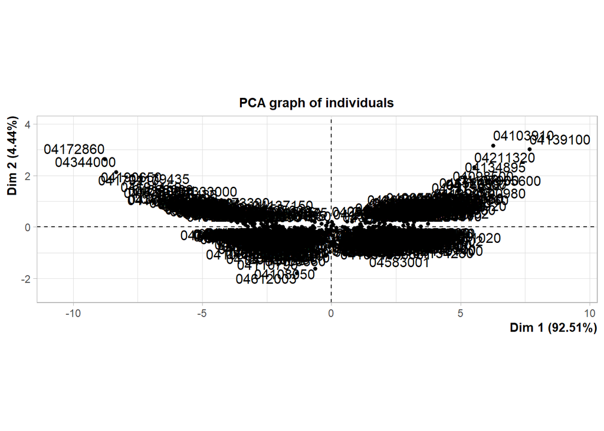

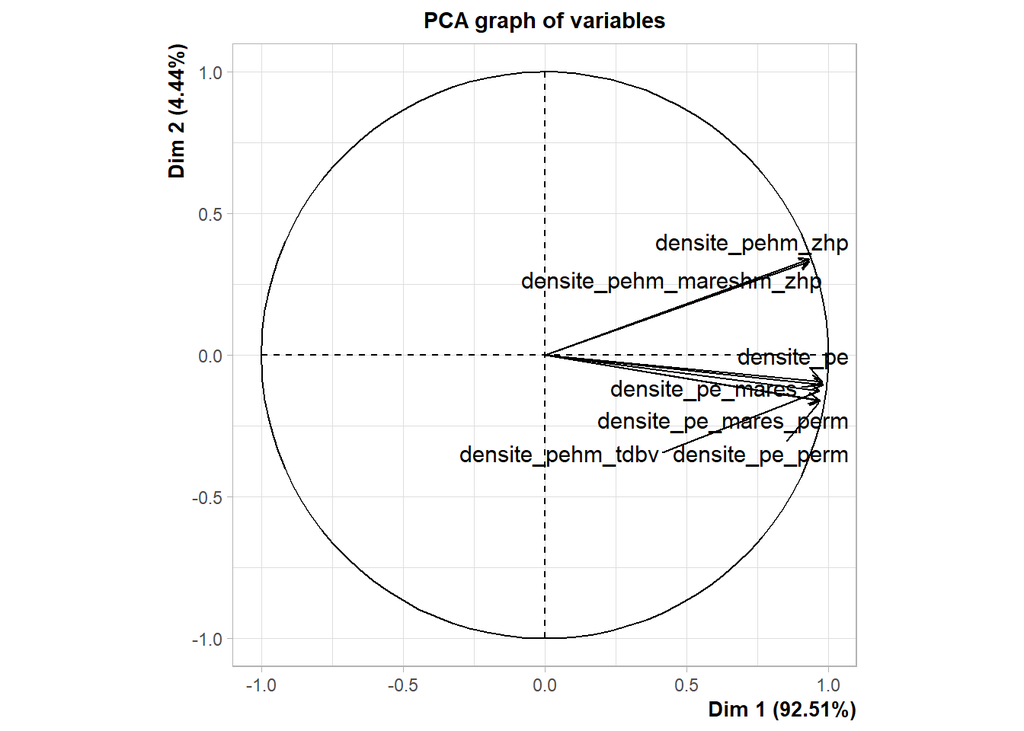

- *Les indicateurs de densité numérique des zones humides probables**

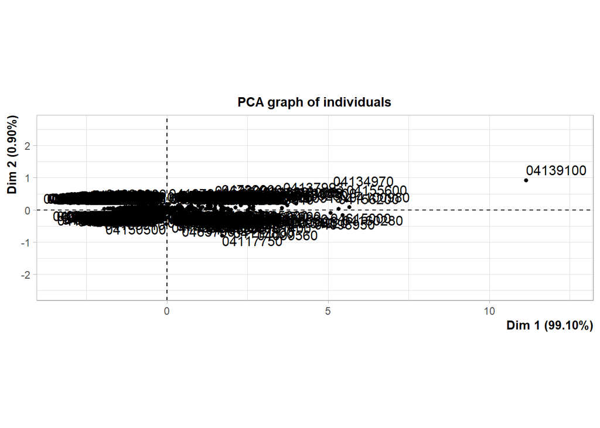

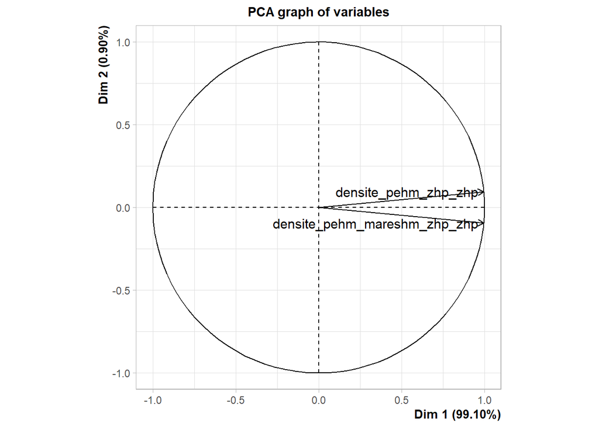

- **Les indicateurs de densité numérique des plans d’eau connectés et sur cours**

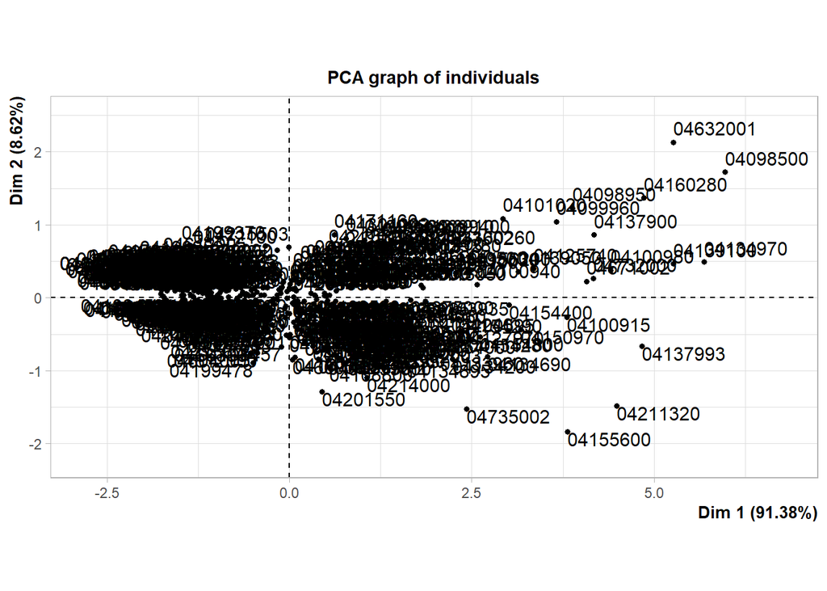

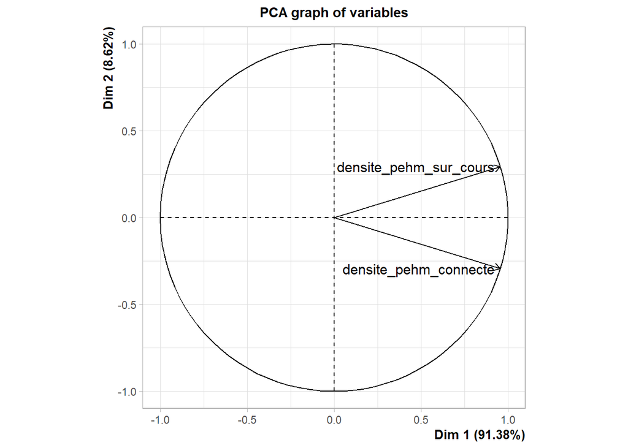

## Modélisation du lien de corrélation avec le score IPR

### A partir de l’échantillon complet et de l’ensemble des variables et co-variables

#### Graphique de corrélation

Nous effectuons ensuite un test de corrélation de ces variables et ACP entres-elles :

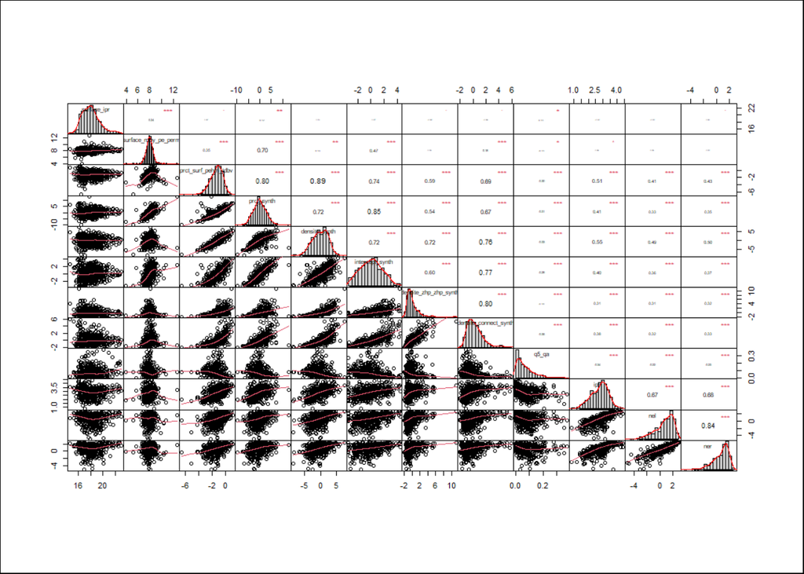

Nous souhaitons alors modéliser (=prédire) la note IPR (et ses métriques) en fonction de variables de pressions (et de co-variables).

#### Plot(mod1) : étude de la répartition de valeurs de l’échantillon

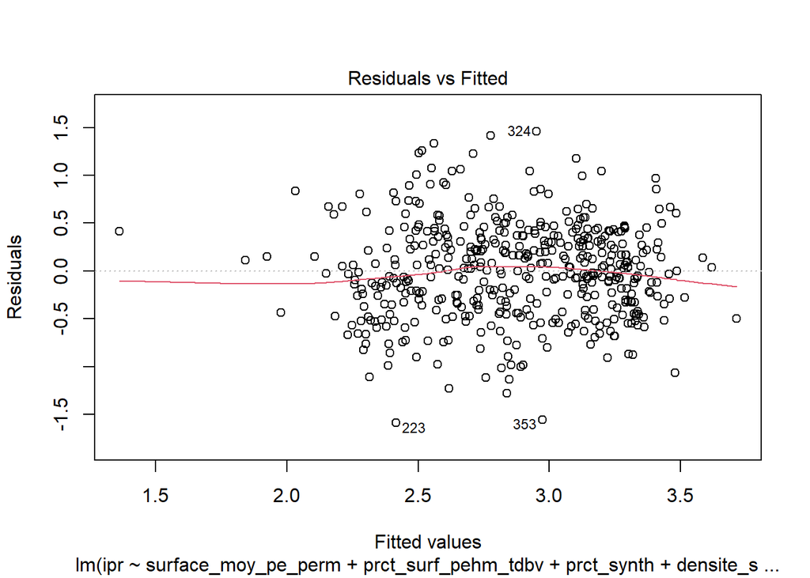

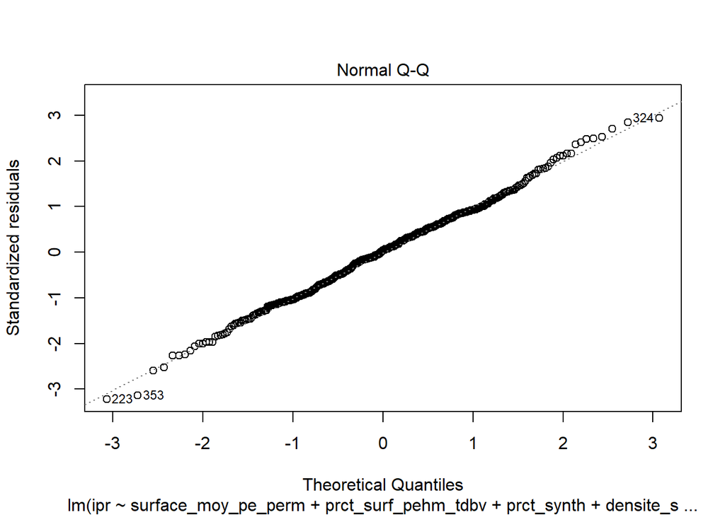

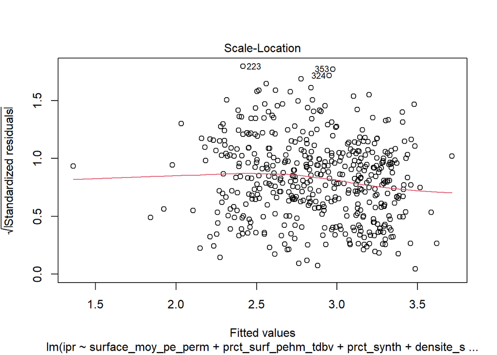

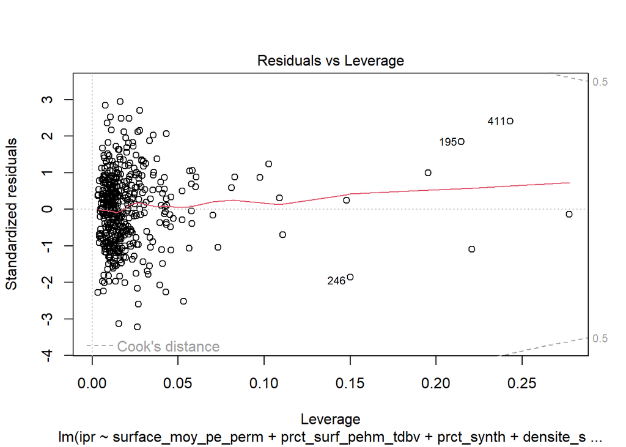

Le premier jeux de graphiques indique qu’il n’y a pas de lien entre le résidu (qui échappe au modèle, en Y) et les valeurs prédites (score IPR en x).

Le second jeux de graphiques indique que la distribution des résidus (qui échappent au modèle) est normale : les points sont alignés sur la droite, il n’y a donc pas de sur ou sous-estimation des scores en fonction des gammes de valeurs rencontrées).

Le troisième jeux de graphiques indique qu’il n’y a pas de point qui sur-influence le modèle (il y aurait sinon 2 courbes rouges, les points à l’écart seraient en situation de sur-influencer le modèle).

**Le respect dans ce cas d’étude de ces quatre modalités de répartition des valeurs de l’échantillon indique qu’il n’y a pas de violation des hypothèses du modèle linéaire.**

```
##
## Call:
## lm(formula = ipr ~ densite_synth + densite_zhp_zhp_synth + q5_qa +
##     taux_drain, data = stat_corr_bv_ipr)
##
## Residuals:
##      Min       1Q   Median       3Q      Max
## -1.57805 -0.34766  0.02658  0.32822  1.50706
##
## Coefficients:
##                         Estimate Std. Error t value Pr(>|t|)
## (Intercept)              3.24693    0.10275  31.601  < 2e-16 ***
## densite_synth            0.13751    0.01422   9.672  < 2e-16 ***
## densite_zhp_zhp_synth   -0.06275    0.02406  -2.608  0.00941 **
## q5_qa                   -1.69251    0.36699  -4.612 5.18e-06 ***
## taux_drain            -180.00717   64.14074  -2.806  0.00522 **
## ---
## Signif. codes:  0 '***' 0.001 '**' 0.01 '*' 0.05 '.' 0.1 ' ' 1
##
## Residual standard error: 0.4976 on 460 degrees of freedom
## Multiple R-squared:  0.3505, Adjusted R-squared:  0.3448
## F-statistic: 62.05 on 4 and 460 DF,  p-value: < 2.2e-16
```

Le R² obtenu dans cette modélisation est de 0,34, indiquant que le score de 34% de l’échantillon peut être expliqué par la variable densité numérique de plans d’eau combinée aux co-variables ratio de débit et taux naturel de drainage (toutes deux inversement corrélées).

Cette modélisation indique donc que :

### En limitant l’analyse aux objets (bv IPR) dont la distance de cook est inférieure à 0,01 (qui s’écartent le plus de la modélisation)

On génère ainsi une nouvelle série d’analyses, en écartant les objets “atypiques” les plus éloignés de la modélisation :

#### Graphique de corrélation

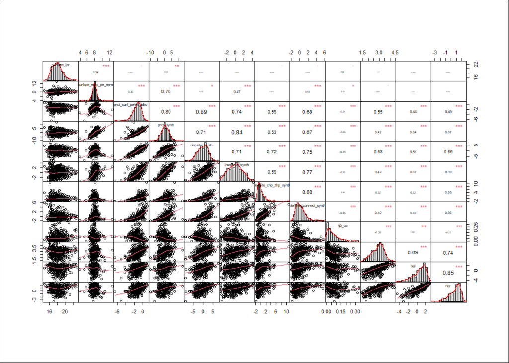

```
##
## Call:
## lm(formula = ipr ~ surface_moy_pe_perm + prct_surf_pehm_tdbv +
##     prct_synth + densite_synth + intercept_synth + densite_zhp_zhp_synth +
##     densite_connect_synth + q5_qa + taux_drain, data = stat_corr_bv_ipr_lim)
##
## Residuals:
##      Min       1Q   Median       3Q      Max
## -1.53787 -0.32775  0.02159  0.32120  1.46990
##
## Coefficients:
##                         Estimate Std. Error t value Pr(>|t|)
## (Intercept)            3.727e+00  6.164e-01   6.046 3.22e-09 ***
## surface_moy_pe_perm   -4.480e-02  7.487e-02  -0.598   0.5499
## prct_surf_pehm_tdbv    5.568e-02  5.771e-02   0.965   0.3351
## prct_synth             1.113e-02  2.919e-02   0.381   0.7032
## densite_synth          1.078e-01  2.736e-02   3.939 9.54e-05 ***
## intercept_synth        4.196e-03  3.009e-02   0.139   0.8892
## densite_zhp_zhp_synth -7.469e-02  3.042e-02  -2.455   0.0145 *
## densite_connect_synth  2.336e-02  4.148e-02   0.563   0.5736
## q5_qa                 -1.591e+00  4.021e-01  -3.956 8.90e-05 ***
## taux_drain            -2.207e+02  7.468e+01  -2.955   0.0033 **
## ---
## Signif. codes:  0 '***' 0.001 '**' 0.01 '*' 0.05 '.' 0.1 ' ' 1
##
## Residual standard error: 0.4724 on 430 degrees of freedom
## Multiple R-squared:  0.3889, Adjusted R-squared:  0.3761
## F-statistic:  30.4 on 9 and 430 DF,  p-value: < 2.2e-16
```

#### Plot(mod1) :

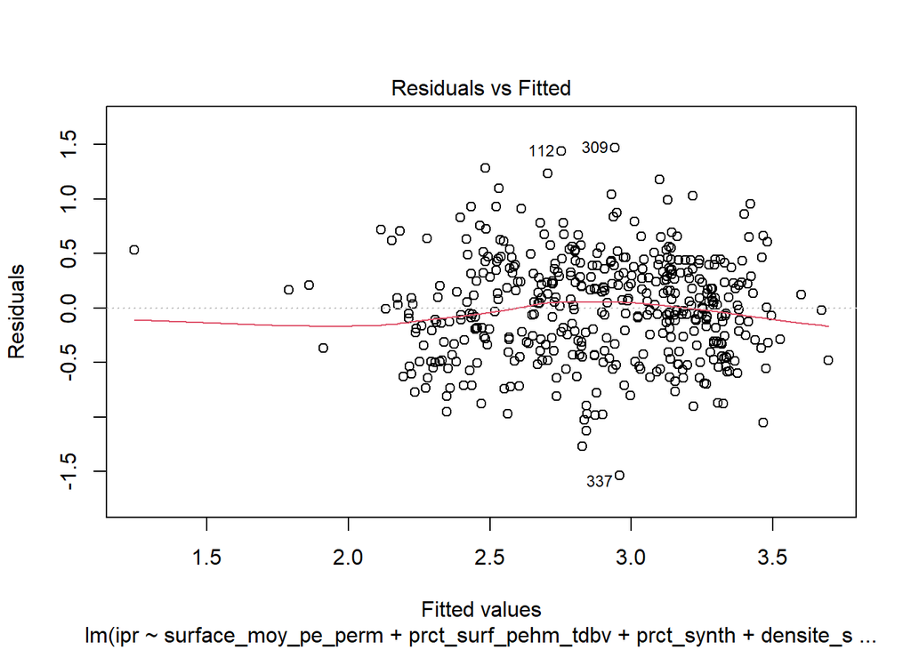

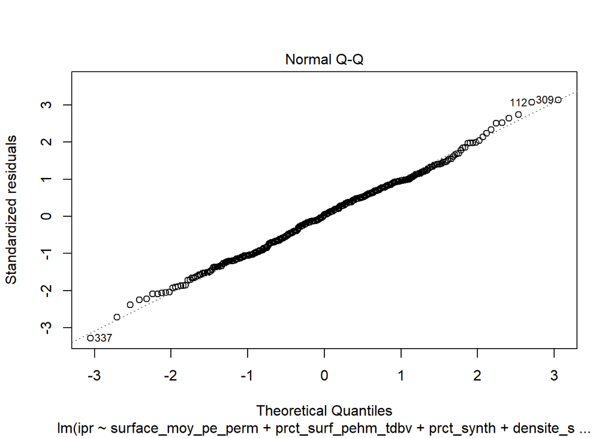

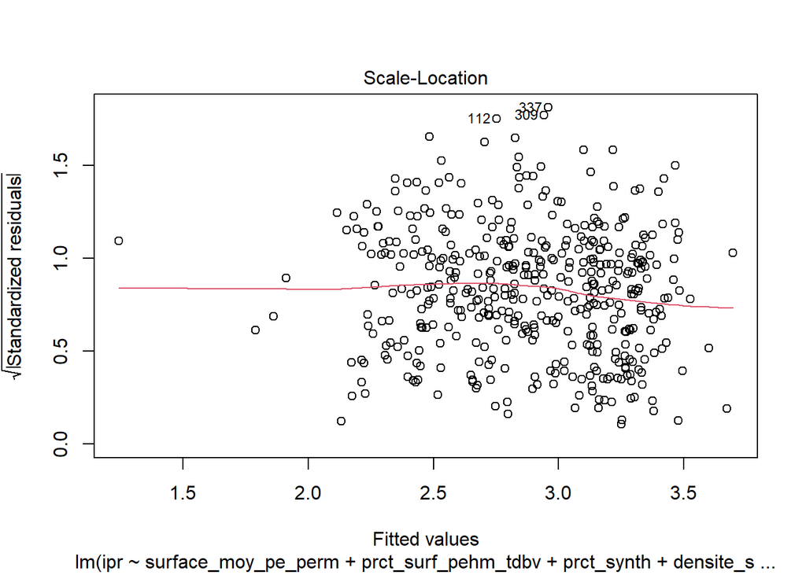

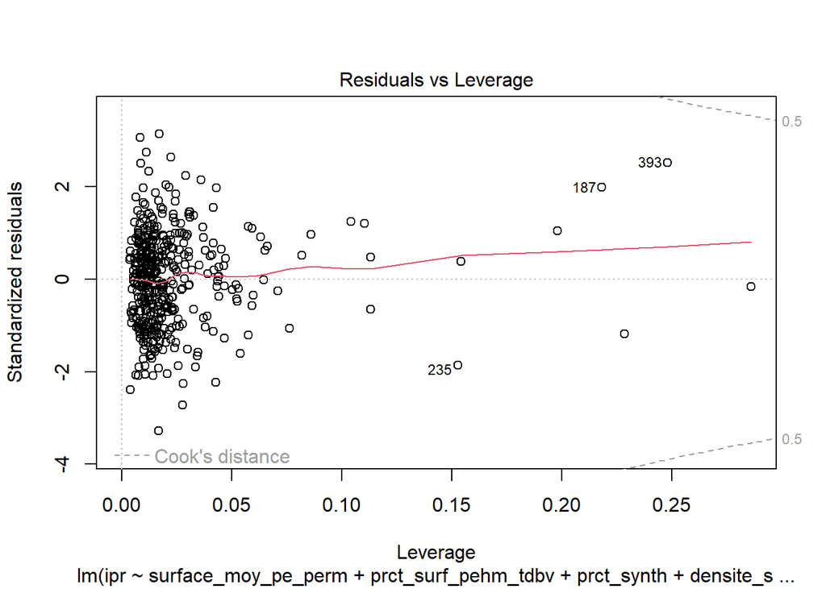

#### Plot(mod2) :

```
##
## Call:
## lm(formula = ipr ~ densite_synth + densite_zhp_zhp_synth + q5_qa +
##     taux_drain, data = stat_corr_bv_ipr_lim)
##
## Residuals:
##      Min       1Q   Median       3Q      Max
## -1.52366 -0.32758  0.02455  0.32064  1.52455
##
## Coefficients:
##                         Estimate Std. Error t value Pr(>|t|)
## (Intercept)              3.27435    0.10272  31.877  < 2e-16 ***
## densite_synth            0.14133    0.01386  10.195  < 2e-16 ***
## densite_zhp_zhp_synth   -0.06274    0.02328  -2.696  0.00730 **
## q5_qa                   -1.68059    0.39227  -4.284 2.26e-05 ***
## taux_drain            -197.04936   64.72058  -3.045  0.00247 **
## ---
## Signif. codes:  0 '***' 0.001 '**' 0.01 '*' 0.05 '.' 0.1 ' ' 1
##
## Residual standard error: 0.4709 on 435 degrees of freedom
## Multiple R-squared:  0.3855, Adjusted R-squared:  0.3799
## F-statistic: 68.23 on 4 and 435 DF,  p-value: < 2.2e-16
```

Cette seconde modélisation propose les même variables et co-variables explicatives du score IPR que la précédente avec toutefois une amélioration de la significativité avec un R² de O,38.

### En limitant l’analyse aux objets (bv IPR) dont la distance de cook est inférieure à 0,01 et aux 20% des BV les plus petits

On cherche ici à s’affranchir des pressions cumulées tierces (moins prégnantes sur de plus petites territoires). On génère ainsi une nouvelle série d’analyses :

#### Graphique de corrélation

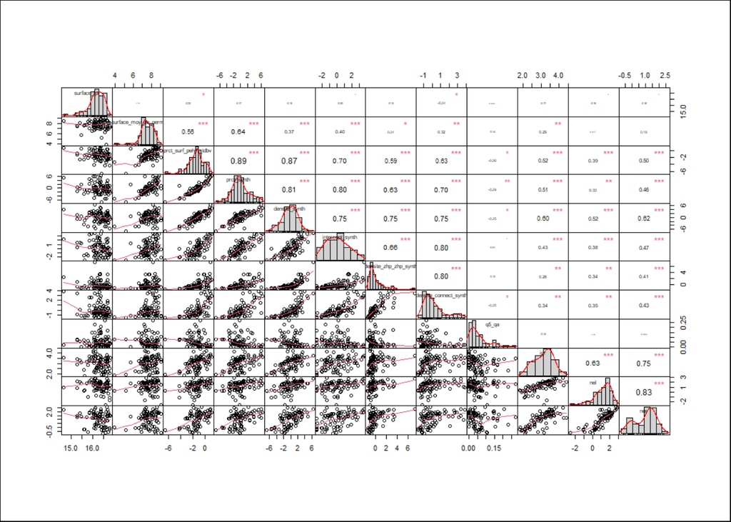

```
##
## Call:
## lm(formula = ipr ~ surface_moy_pe_perm + prct_surf_pehm_tdbv +
##     prct_synth + densite_synth + intercept_synth + densite_zhp_zhp_synth +
##     densite_connect_synth + q5_qa + taux_drain, data = stat_corr_bv_ipr_lim_bv)
##
## Residuals:
##      Min       1Q   Median       3Q      Max
## -0.95540 -0.34121  0.09592  0.26569  1.38297
##
## Coefficients:
##                        Estimate Std. Error t value Pr(>|t|)
## (Intercept)             2.10157    0.77252   2.720   0.0081 **
## surface_moy_pe_perm     0.05679    0.08930   0.636   0.5267
## prct_surf_pehm_tdbv    -0.13715    0.10789  -1.271   0.2076
## prct_synth              0.03160    0.05813   0.544   0.5884
## densite_synth           0.26527    0.05577   4.757 9.32e-06 ***
## intercept_synth         0.02067    0.06596   0.313   0.7549
## densite_zhp_zhp_synth  -0.14733    0.07012  -2.101   0.0390 *
## densite_connect_synth  -0.09655    0.08615  -1.121   0.2660
## q5_qa                   0.23595    0.95361   0.247   0.8052
## taux_drain            210.18901  146.74430   1.432   0.1562
## ---
## Signif. codes:  0 '***' 0.001 '**' 0.01 '*' 0.05 '.' 0.1 ' ' 1
##
## Residual standard error: 0.4732 on 75 degrees of freedom
## Multiple R-squared:  0.458,  Adjusted R-squared:  0.393
## F-statistic: 7.042 on 9 and 75 DF,  p-value: 2.613e-07
```

#### Plot(mod1) :

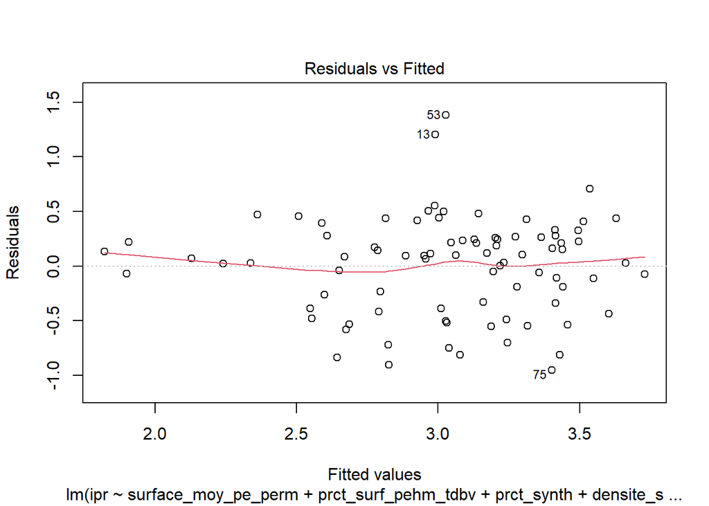

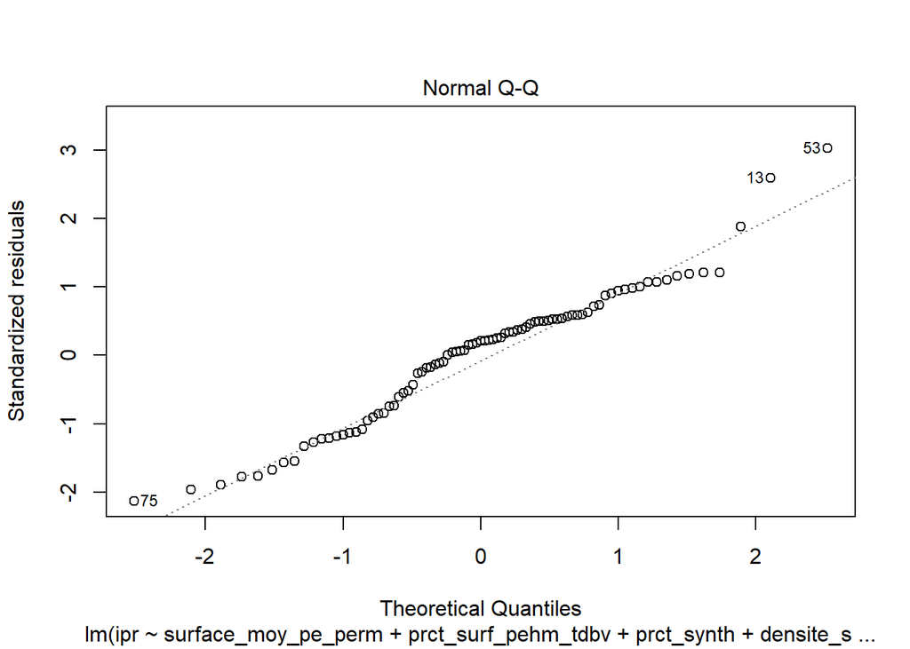

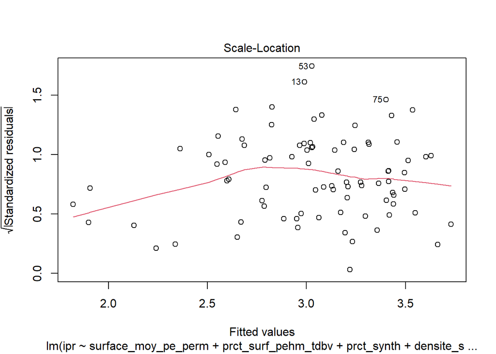

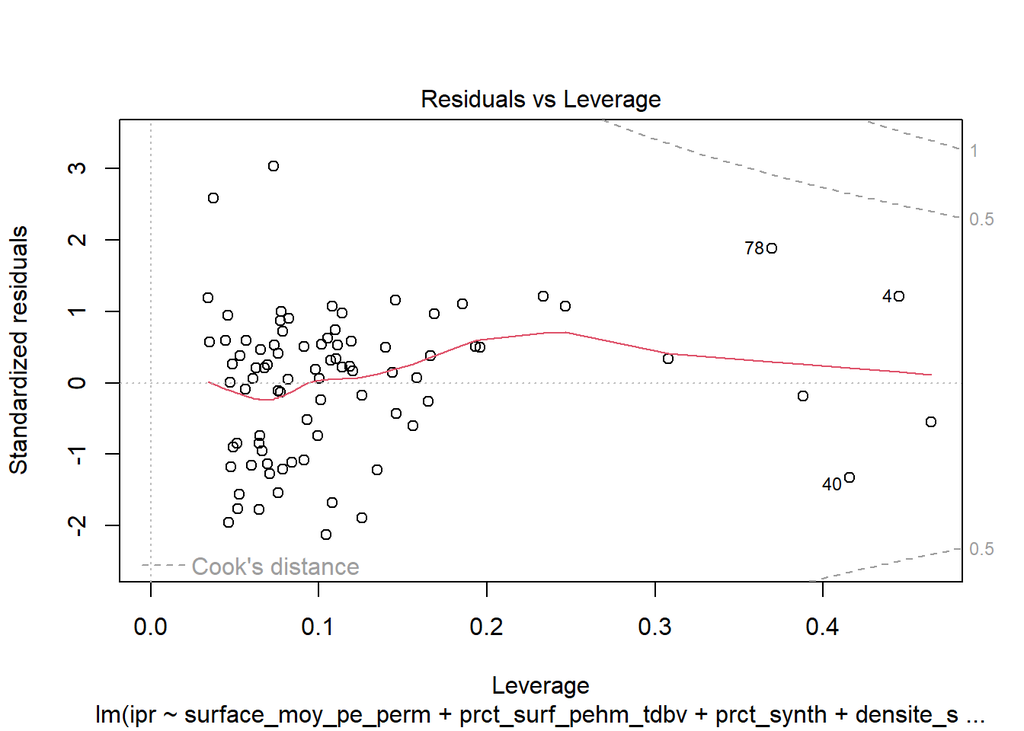

#### Plot(mod2) :

```
##
## Call:
## lm(formula = ipr ~ densite_synth + densite_zhp_zhp_synth + taux_drain,
##     data = stat_corr_bv_ipr_lim_bv)
##
## Residuals:
##     Min      1Q  Median      3Q     Max
## -0.9541 -0.3423  0.1005  0.2738  1.3420
##
## Coefficients:
##                        Estimate Std. Error t value Pr(>|t|)
## (Intercept)             2.76642    0.18856  14.671  < 2e-16 ***
## densite_synth           0.21580    0.03048   7.081  4.7e-10 ***
## densite_zhp_zhp_synth  -0.17044    0.05430  -3.139  0.00237 **
## taux_drain            186.28212  126.42312   1.473  0.14450
## ---
## Signif. codes:  0 '***' 0.001 '**' 0.01 '*' 0.05 '.' 0.1 ' ' 1
##
## Residual standard error: 0.4649 on 81 degrees of freedom
## Multiple R-squared:  0.435,  Adjusted R-squared:  0.4141
## F-statistic: 20.79 on 3 and 81 DF,  p-value: 4.401e-10
```

Cette dernière modélisation ressort moins de co-variables (la ratio de débits disparait de la modélisation). La pression densité numérique de plans d’eau reste l’ACP la mieux corrélée, les co-variables de manière moins significatives. Le R² obtenu dans cette modélisation est de 0,41, indiquant que le score de 41% de l’échantillon peut être expliqué par la variable densité numérique de plans d’eau et ses co-variables.

## Modélisation du lien de corrélation avec le score de la métrique IPR NER

Le Score de la métrique “Nombre d’Espèces Rhéophiles (NER)” traduit la qualité du bassin versant au regard de ses espèces réophiles. Il nous semble un bon reflet de l’impact des plans d’eau par lentification des milieux aquatiques. Aussi l’avons nous retenu pour analyse.

### Ensemble de l’échantillon

#### Plot(mod1) :

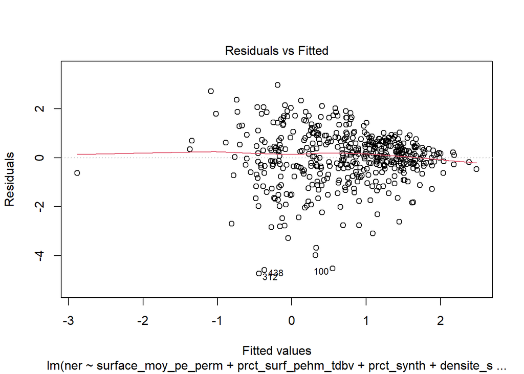

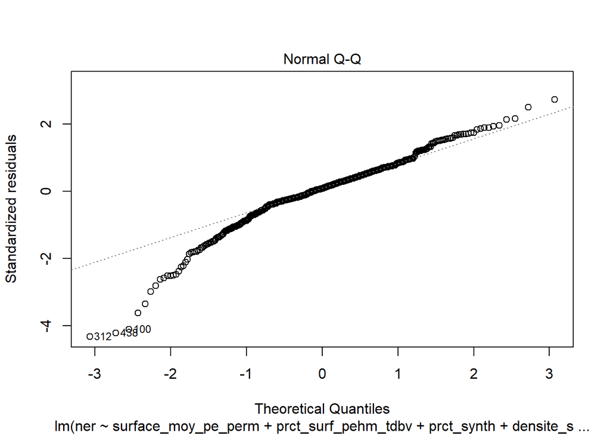

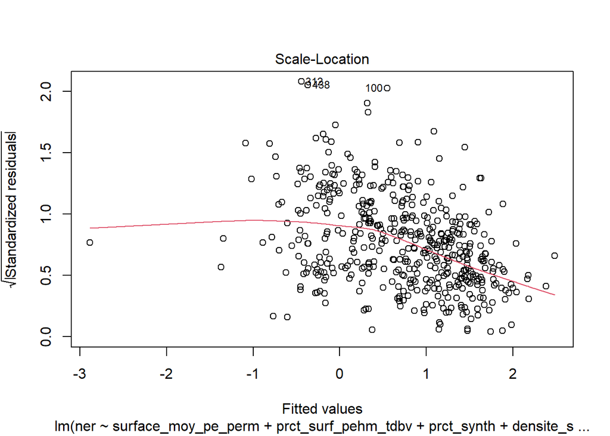

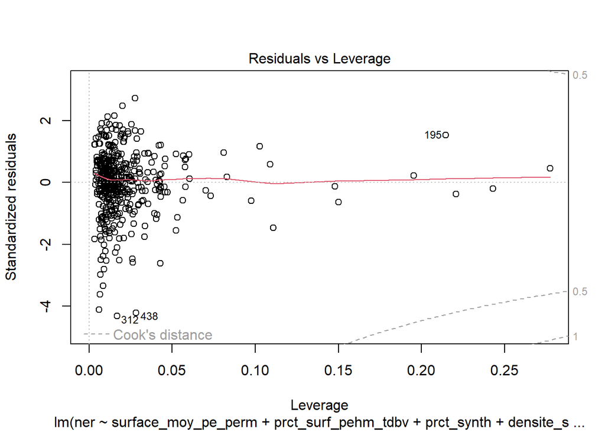

#### Plot(mod2) :

```
##
## Call:
## lm(formula = ner ~ densite_synth + q5_qa + taux_drain, data = stat_corr_bv_ipr)
##
## Residuals:
##     Min      1Q  Median      3Q     Max
## -4.8951 -0.4580  0.1084  0.6460  2.8486
##
## Coefficients:
##                 Estimate Std. Error t value Pr(>|t|)
## (Intercept)      2.06700    0.22557   9.163  < 2e-16 ***
## densite_synth    0.21901    0.02191   9.994  < 2e-16 ***
## q5_qa           -2.40454    0.80890  -2.973  0.00311 **
## taux_drain    -819.68629  141.08639  -5.810 1.17e-08 ***
## ---
## Signif. codes:  0 '***' 0.001 '**' 0.01 '*' 0.05 '.' 0.1 ' ' 1
##
## Residual standard error: 1.104 on 461 degrees of freedom
## Multiple R-squared:  0.3095, Adjusted R-squared:  0.305
## F-statistic: 68.87 on 3 and 461 DF,  p-value: < 2.2e-16
```